# Performing meta-analyses of microbiome cohorts with MMUPHin

# 4 Performing batch (study) effect adjustment with `adjust_batch`

`adjust_batch` aims to correct for technical study/batch effects in microbial feature abundances. It takes as input the feature-by-sample abundance matrix, and performs batch effect adjustment given provided batch and optional covariate variables. It returns the batch-adjusted abundance matrix. Check `help(adjust_batch)` for additional details and options.

Here we use `adjust_batch` to correct for differences in the five studies, while controlling for the effect of CRC versus control (variable `study_condition` in `CRC_meta`).

```r
# The function call indicates for adjust_batch to correct for the effect
# of the batch variable, studyID, while controlling for the effect of the
# disease variable, study_condition. Many additional options are available
# through the control parameter, here we specify verbose=FALSE to avoid
# excessive messages, although they can often be helpful in practice!
fit_adjust_batch <- adjust_batch(feature_abd = CRC_abd,
                                 batch = "studyID",
                                 covariates = "study_condition",
                                 data = CRC_meta,
                                 control = list(verbose = FALSE))
# Note that adjust_batch returns a list of more than one components, and
# feature_abd_adj is the corrected feature abundance matrix. See
# help(adjust_batch) for the meaning of other components.
CRC_abd_adj <- fit_adjust_batch$feature_abd_adj
```

One way to evaluate the effect of batch adjustment is to assess the total variability in microbial profiles attributable to study differences, before and after adjustment. This is commonly known as a PERMANOVA test (Tang, Chen, and Alekseyenko 2016), and can be performed with the `adonis` function in *vegan*.

```r
library(vegan)
# adonis requires as input sample-versus-sample dissimilarities between
# microbial profiles
D_before <- vegdist(t(CRC_abd))
D_after <- vegdist(t(CRC_abd_adj))
# fix random seed as adonis runs randomized permutations
set.seed(1)
fit_adonis_before <- adonis(D_before ~ studyID, data = CRC_meta)
fit_adonis_after <- adonis(D_after ~ studyID, data = CRC_meta)
print(fit_adonis_before)
```

```
##
## Call:
## adonis(formula = D_before ~ studyID, data = CRC_meta)
##
## Permutation: free
## Number of permutations: 999
##
## Terms added sequentially (first to last)
##
##            Df SumsOfSqs MeanSqs F.Model      R2 Pr(>F)
## studyID     4     13.36  3.3400  11.855 0.07991  0.001 ***
## Residuals 546    153.82  0.2817         0.92009
## Total     550    167.18                 1.00000
## ---
## Signif. codes:  0 '***' 0.001 '**' 0.01 '*' 0.05 '.' 0.1 ' ' 1
```

```r
print(fit_adonis_after)
```

```
##
## Call:
## adonis(formula = D_after ~ studyID, data = CRC_meta)
##
## Permutation: free
## Number of permutations: 999
##
## Terms added sequentially (first to last)
##
##            Df SumsOfSqs MeanSqs F.Model      R2 Pr(>F)
## studyID     4    10.315 2.57863  9.0054 0.06189  0.001 ***
## Residuals 546   156.344 0.28634         0.93811
## Total     550   166.658                 1.00000
## ---
## Signif. codes:  0 '***' 0.001 '**' 0.01 '*' 0.05 '.' 0.1 ' ' 1
```

We can see that, before study effect adjustment, study differences can expalin a total of 7.99% of the variability in microbial abundance profiles, whereas after adjustment this was reduced to 6.19%, though the effect of study is significant in both cases.

# 5 Meta-analytical differential abundance testing with `lm_meta`

One of the most common meta-analysis goals is to combine association effects across batches/studies to identify consistent overall effects. `lm_meta` provides a straightforward interface to this task, by first performing regression analysis in individual batches/studies using the well-validated *Maaslin2* packge, and then aggregating results with established fixed/mixed effect models, realized via the *vegan* package. Here, we use `lm_meta` to test for consistently differential abundant species between CRC and control samples across the five studies, while controlling for demographic covariates (gender, age, BMI).

```r
# lm_meta runs regression and meta-analysis models to identify consistent
# effects of the exposure (study_condition, i.e., disease) on feature_abd
# (microbial feature abundances). Batch variable (studyID) needs to be
# specified to identify different studies. Additional covariates to include in
# the regression model can be specified via covariates (here set to gender,
# age, BMI). Check help(lm_meta) for additional parameter options.
# Note the warnings: lm_meta can tell if a covariate cannot be meaningfully fit
# within a batch and will inform the user of such cases through warnings.
fit_lm_meta <- lm_meta(feature_abd = CRC_abd,
                       batch = "studyID",
                       exposure = "study_condition",
                       covariates = c("gender", "age", "BMI"),
                       data = CRC_meta,
                       control = list(verbose = FALSE))
# Again, lm_meta returns a list of more than one components.
# meta_fits provides the final meta-analytical testing results. See
# help(lm_meta) for the meaning of other components.
meta_fits <- fit_lm_meta$meta_fits
```

We can visualize the significant (FDR q < 0.05) species associated with CRC in these studies/samples. Comparing them with Figure 1b of Thomas et al. (2019), we can see that many of the significant species do agree.

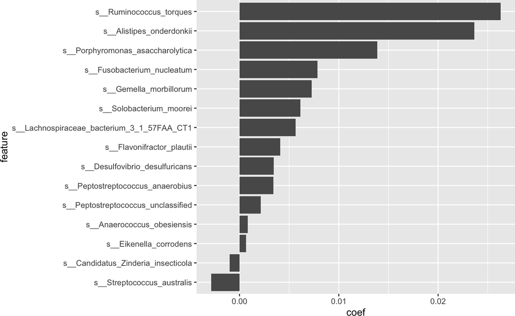

```r
meta_fits %>%
  filter(qval.fdr < 0.05) %>%
  arrange(coef) %>%
  mutate(feature = factor(feature, levels = feature)) %>%
  ggplot(aes(y = coef, x = feature)) +
  geom_bar(stat = "identity") +
  coord_flip()
```

# 6 Identifying discrete population structures with `discrete_discover`

Clustering analysis of microbial profiles can help identify meaningful discrete population subgroups (Ravel et al. 2011), but must be carried out carefully with validations to ensure that the identified structures are consistent (Koren et al. 2013). `discrete_discover` provides the functionality to use prediction strength (Tibshirani and Walther 2005) to evaluate discrete clustering structures within individual microbial cohorts, as well as a “generalized predicition strength” to evaluate their reproducibility in additional cohorts. These jointly provide meta-analytical evidence for (or against) identifying discrete population structures in microbial profiles. Check `help(discrete_discover)` to see more details on the method, options, and, importantly, how to interpret the output.

The gut microbiome is known to form gradients rather than discrete clusters (Koren et al. 2013). Here we use `discrete_discover` to evaluate clustering structures among CRC patients in the five CRC stool studies.

```r
# First subset both feature abundance table and metadata to only CRC patients
CRC_meta_disease <- subset(CRC_meta, study_condition == "CRC")
CRC_abd_adj_disease <- CRC_abd_adj[, rownames(CRC_meta_disease)]
# discrete_discover takes as input sample-by-sample dissimilarity measurements
# rather than abundance table. The former can be easily computed from the
# latter with existing R packages.
D_disease <- vegdist(t(CRC_abd_adj_disease))
fit_discrete <- discrete_discover(D = D_disease,
                                  batch = "studyID",
                                  data = CRC_meta_disease,
                                  control = list(k_max = 8,
                                                 verbose = FALSE))
```

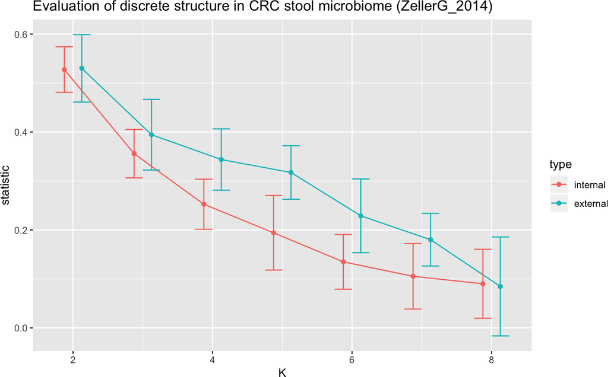

```r
internal <- data.frame(
  # By default, fit_discrete evaluates cluster numbers 2-10
  K = 2:8,
  statistic =
    fit_discrete$internal_mean[, "ZellerG_2014.metaphlan_bugs_list.stool"],
  se =
    fit_discrete$internal_se[, "ZellerG_2014.metaphlan_bugs_list.stool"],
  type = "internal")
external <- data.frame(
  # By default, fit_discrete evaluates cluster numbers 2-10
  K = 2:8,
  statistic =
    fit_discrete$external_mean[, "ZellerG_2014.metaphlan_bugs_list.stool"],
  se =
    fit_discrete$external_se[, "ZellerG_2014.metaphlan_bugs_list.stool"],
  type = "external")
rbind(internal, external) %>%
  ggplot(aes(x = K, y = statistic, color = type)) +
  geom_point(position = position_dodge(width = 0.5)) +
  geom_line(position = position_dodge(width = 0.5)) +
  geom_errorbar(aes(ymin = statistic - se, ymax = statistic + se),
                position = position_dodge(width = 0.5), width = 0.5) +
  ggtitle("Evaluation of discrete structure in CRC stool microbiome (ZellerG_2014)")
```

The decreasing trend for both the internal and external statistics along with number of clusters (K) suggests that discrete structures cannot be well-established. To provide a positive example, we examine the two vaginal microbiome studies provided by *curatedMetagenomicData*, as the vaginal microbiome is known to have distinct subtypes (Ravel et al. 2011). Again, we pre-formatted these datasets for easy access, but you can recreate them from *curatedMetagenomicData* with the commented out scripts.

```r
# library(curatedMetagenomicData)
# library(phyloseq)
# datasets <- curatedMetagenomicData(
#   "*metaphlan_bugs_list.vagina*",
#   dryrun = FALSE)
# # Construct phyloseq object from the five datasets
# physeq <-
#   # Aggregate the five studies into ExpressionSet
#   mergeData(datasets) %>%
#   # Convert to phyloseq object
#   ExpressionSet2phyloseq() %>%
#   # Subset features to species
#   subset_taxa(!is.na(Species) & is.na(Strain)) %>%
#   # Normalize abundances to relative abundance scale
#   transform_sample_counts(function(x) x / sum(x)) %>%
#   # Filter features to be of at least 1e-5 relative abundance in two samples
#   filter_taxa(kOverA(2, 1e-5), prune = TRUE)
# vaginal_abd <- otu_table(physeq)@.Data
# vaginal_meta <- data.frame(sample_data(physeq))
# vaginal_meta$studyID <- factor(vaginal_meta$studyID)
data("vaginal_abd", "vaginal_meta")
D_vaginal <- vegdist(t(vaginal_abd))
fit_discrete_vag <- discrete_discover(D = D_vaginal,
                                      batch = "studyID",
                                      data = vaginal_meta,
                                      control = list(verbose = FALSE,
                                                     k_max = 8))
```

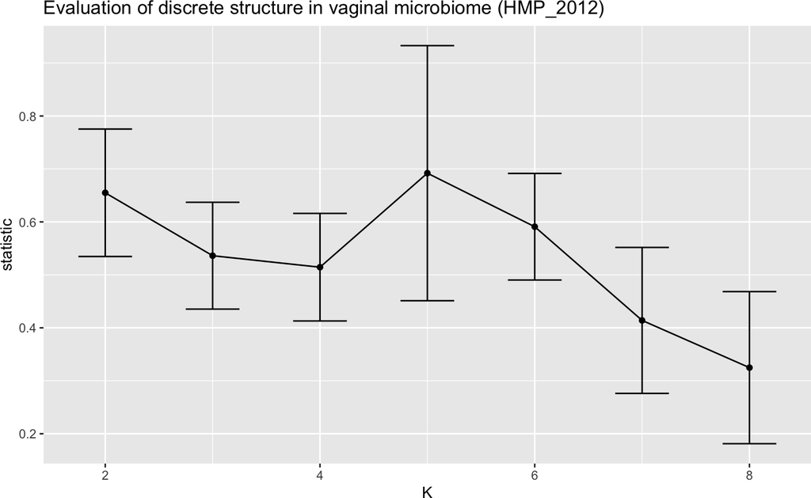

```r
# Examine results for the larger study, HMP_2012
data.frame(
  # By default, fit_discrete evaluates cluster numbers 2-10
  K = 2:8,
  statistic =
    fit_discrete_vag$internal_mean[, "HMP_2012.metaphlan_bugs_list.vagina"],
  se =
    fit_discrete_vag$internal_se[, "HMP_2012.metaphlan_bugs_list.vagina"]) %>%
  ggplot(aes(x = K, y = statistic)) +
  geom_point() + geom_line() +
  geom_errorbar(aes(ymin = statistic - se, ymax = statistic + se),
                width = 0.5) +
  ggtitle("Evaluation of discrete structure in vaginal microbiome (HMP_2012)")
```

We can see that for the vaginal microbiome, `discrete_discover` suggests the existence of five clusters. Here we examine only the internal metrics of HMP_2012 as the other study (FerrettiP_2018) has only 19 samples.